# Cracking the Kaggle project-Quora question pair

This is the Kaggle project Quora Question Pairs competition: https://www.kaggle.com/c/quora-question-pairs. The goal for this challange is to compare two questions from quora, and identify if they're duplicate. This can come very useful when there are tons of questions being asked every day, and consolidate the answer for the convenience of users.

This aritile provide a comprehensive step-by-step code of solutions, from data exploration, handcrafted featureing, (including the discovery of magic features), to training the model by serveal machine learning agrolritms (random forest, deep learning, xgboost), and pick the winner.

We currently are ranking as 300/2800th on the leader board.

Let's dive into the data.

## Exploratary analysis

```python
import numpy as np # linear algebra
import pandas as pd # data processing, CSV file I/O (e.g. pd.read_csv)
import os
import gc
import matplotlib.pyplot as plt
import seaborn as sns
%matplotlib inline

df_train = pd.read_csv('/Users/coolfish/Documents/Kaggle_Quora/raw file/train.csv')
df_train.head()
```

|  | id | qid1 | qid2 | question1 | question2 | is_duplicate |
| --- | --- | --- | --- | --- | --- | --- |
| 0 | 0 | 1 | 2 | What is the step by step guide to invest in sh... | What is the step by step guide to invest in sh... | 0 |
| 1 | 1 | 3 | 4 | What is the story of Kohinoor (Koh-i-Noor) Dia... | What would happen if the Indian government sto... | 0 |
| 2 | 2 | 5 | 6 | How can I increase the speed of my internet co... | How can Internet speed be increased by hacking... | 0 |
| 3 | 3 | 7 | 8 | Why am I mentally very lonely? How can I solve... | Find the remainder when [math]23^{24}[/math] i... | 0 |
| 4 | 4 | 9 | 10 | Which one dissolve in water quikly sugar, salt... | Which fish would survive in salt water? | 0 |

```python
df_test = pd.read_csv('/Users/coolfish/Documents/Kaggle_Quora/raw file/test.csv')
df_test.head()
```

|  | test_id | question1 | question2 |
| --- | --- | --- | --- |
| 0 | 0 | How does the Surface Pro himself 4 compare wit... | Why did Microsoft choose core m3 and not core ... |
| 1 | 1 | Should I have a hair transplant at age 24? How... | How much cost does hair transplant require? |
| 2 | 2 | What but is the best way to send money from Ch... | What you send money to China? |
| 3 | 3 | Which food not emulsifiers? | What foods fibre? |
| 4 | 4 | How "aberystwyth" start reading? | How their can I start reading? |

id: Looks like a simple rowID

qid{1, 2}: The unique ID of each question in the pair

question{1, 2}: The actual textual contents of the questions.

is_duplicate: The label that we are trying to predict - whether the two questions are duplicates of each other.

```
mean-train 59.86 std-train 31.99 mean-test 60.11 std-test 31.66 max-train 1169.00 max-test 1176.00
```

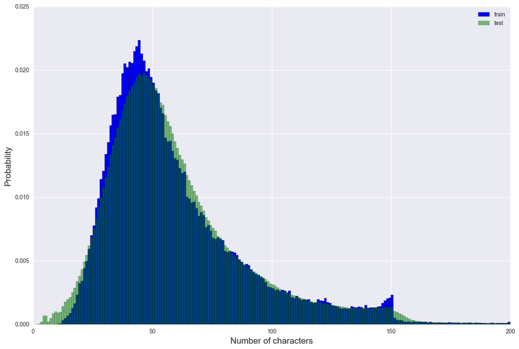

```python
train_qs = pd.Series(df_train['question1'].tolist() + df_train['question2'].tolist()).astype(str)
test_qs = pd.Series(df_test['question1'].tolist() + df_test['question2'].tolist()).astype(str)

dist_train = train_qs.apply(len)
dist_test = test_qs.apply(len)
plt.figure(figsize=(15, 10))
plt.hist(dist_train, bins=200, range=[0, 200], color='blue', normed=True, label='train')
plt.hist(dist_test, bins=200, range=[0, 200], color='green', normed=True, alpha=0.5, label='test')
plt.legend()
plt.xlabel('Number of characters', fontsize=15)
plt.ylabel('Probability', fontsize=15)

print('mean-train {:.2f} std-train {:.2f} mean-test {:.2f} std-test {:.2f} max-train {:.2f} max-test {:.2f}'.format(dist_train.mean(),
                          dist_train.std(), dist_test.mean(), dist_test.std(), dist_train.max(), dist_test.max()))
```

## Handcrafted featurings

In order to analyze the file, we need translate the text into nums, so the computer can understand and be able to calculate. There are tons of ways to do so. I will use something called TF-IDF (term-frequency-inverse-document-frequency). TF is to calculate how many terms are in common from both questions, IDF is the inverse document frequency, which means that we weigh the terms by how uncommon they are, meaning that we care more about rare words existing in both questions than common one.

This makes sense, as for example we care more about whether the word "python" appears in both than the words "and" or "the" - as uncommon words will be more indicative of the content. Also, we try to see if stop words like 'an' 'the' would play a role in it, so we will build features based on both.

In the last but not least, we want put bag of words together as normally phases carry out the meaning different from each seperate words.

Due to the gigantic size of this data file and long hours running it, I'll skip running it here and load the results directly.

```python
cd /Users/coolfish/Documents/Kaggle_Quora/features
```

```
/Users/coolfish/Documents/Kaggle_Quora/features
```

This is the outlout of this text to number file

```python
train_num = pd.read_csv('/Users/coolfish/Documents/Kaggle_Quora/features/num_train.csv')
train_num.head()
train_num.columns
```

```
Index([u'is_duplicate', u'1_SWC', u'1_SWC_IDF', u'1_ND', u'1_ND_IDF', u'2_SWC',
       u'2_SWC_IDF', u'2_ND', u'2_ND_IDF', u'3_SWC', u'3_SWC_IDF', u'3_ND',
       u'3_ND_IDF', u'1_SWC_w_stops', u'1_SWC_IDF_w_stops', u'1_ND_w_stops',
       u'1_ND_IDF_w_stops', u'2_SWC_w_stops', u'2_SWC_IDF_w_stops',
       u'2_ND_w_stops', u'2_ND_IDF_w_stops', u'3_SWC_w_stops',
       u'3_SWC_IDF_w_stops', u'3_ND_w_stops', u'3_ND_IDF_w_stops'],
      dtype='object')
```

### Magic Features

This actually did not come to me until much later. Intuitively, we'd think since we're comparing two unique questions.  
The meta data of the whole file (like the questions counts, means, distrbution) doesnt matter. But it turns out the other way. Let's first take a look at the frenqucy distribution.

```
Total number of question pairs for training: 404290
Duplicate pairs: 36.92%
Total number of questions in the training data: 537933
Number of questions that appear multiple times: 111780
()
```

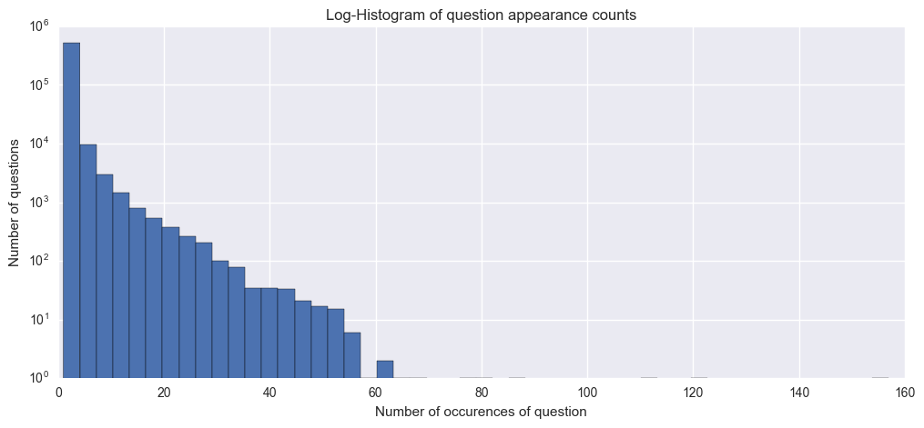

```python
print('Total number of question pairs for training: {}'.format(len(df_train)))
print('Duplicate pairs: {}%'.format(round(df_train['is_duplicate'].mean()*100, 2)))
qids = pd.Series(df_train['qid1'].tolist() + df_train['qid2'].tolist())
print('Total number of questions in the training data: {}'.format(len(
    np.unique(qids))))
print('Number of questions that appear multiple times: {}'.format(np.sum(qids.value_counts() > 1)))

plt.figure(figsize=(12, 5))
plt.hist(qids.value_counts(), bins=50)
plt.yscale('log', nonposy='clip')
plt.title('Log-Histogram of question appearance counts')
plt.xlabel('Number of occurences of question')
plt.ylabel('Number of questions')
print()
```

```python
df1 = df_train[['question1']].copy()
df2 = df_train[['question2']].copy()
df1_test = df_test[['question1']].copy()
df2_test = df_test[['question2']].copy()

df2.rename(columns = {'question2':'question1'},inplace=True)
df2_test.rename(columns = {'question2':'question1'},inplace=True)

train_questions = df1.append(df2)
train_questions = train_questions.append(df1_test)
train_questions = train_questions.append(df2_test)
#train_questions.drop_duplicates(subset = ['qid1'],inplace=True)
train_questions.drop_duplicates(subset = ['question1'],inplace=True)

train_questions.reset_index(inplace=True,drop=True)
questions_dict = pd.Series(train_questions.index.values,index=train_questions.question1.values).to_dict()
train_cp = df_train.copy()
test_cp = df_test.copy()
train_cp.drop(['qid1','qid2'],axis=1,inplace=True)

test_cp['is_duplicate'] = -1
test_cp.rename(columns={'test_id':'id'},inplace=True)
comb = pd.concat([train_cp,test_cp])

comb['q1_hash'] = comb['question1'].map(questions_dict)
comb['q2_hash'] = comb['question2'].map(questions_dict)

q1_vc = comb.q1_hash.value_counts().to_dict()
q2_vc = comb.q2_hash.value_counts().to_dict()

def try_apply_dict(x,dict_to_apply):
    try:
        return dict_to_apply[x]
    except KeyError:
        return 0
#map to frequency space
comb['q1_freq'] = comb['q1_hash'].map(lambda x: try_apply_dict(x,q1_vc) + try_apply_dict(x,q2_vc))
comb['q2_freq'] = comb['q2_hash'].map(lambda x: try_apply_dict(x,q1_vc) + try_apply_dict(x,q2_vc))

#train_comb = comb[comb['is_duplicate'] >= 0][['id','q1_hash','q2_hash','q1_freq','q2_freq','is_duplicate']]
#test_comb = comb[comb['is_duplicate'] < 0][['id','q1_hash','q2_hash','q1_freq','q2_freq']]

train_comb1 = comb[comb['is_duplicate'] >= 0][['id','q1_freq','q2_freq','question1','question2']]
test_comb1 = comb[comb['is_duplicate'] < 0][['id','q1_freq','q2_freq','question1','question2']]
```

Those are the most frequently asked questions.

```python
frindex=train_comb.sort_values(by='q1_freq')['q1_freq'].unique()[-10:]
train_comb[train_comb['q1_freq'].isin(frindex)]['question1'].unique()
```

```
array(['How can I earn money online?', 'How can I lose weight quickly?',
       'What are the best ways to reduce and eliminate belly, abdominal, and thigh fat?',
       'What are the best ways to lose weight?',
       'What are some things new employees should know going into their first day at AT&T?',
       'Can you see who views your Instagram?',
       "What's the easiest way to make money online?",
       'What is the purpose of life?',
       'How can I become fluent in English?',
       'How can you increase your height?'], dtype=object)
```

Now lets get the freqncy as the magic features

## Building models

Now since we got our regular features and magic features. Let us start training some models.

### Random forest

One of the most common machline learning algorithm is random forest. Let's give it a shot.

```python
import sys
import pandas as pd
import numpy as np
from sklearn.metrics import log_loss
from sklearn.cross_validation import train_test_split, KFold
from sklearn.ensemble import RandomForestClassifier
from sklearn.ensemble import RandomForestRegressor

nrows=100000

path = "/Users/coolfish/Documents/Kaggle_Quora/features/"
df = pd.read_csv(path+"train_magic.csv",nrows=nrows)

target = "is_duplicate"
features = list(df.columns.values)
features.remove(target)

kf = KFold(len(df.index),5)
scores = []
for train_index, test_index in kf:
    train, valid = df.iloc[train_index,:], df.iloc[test_index,:]
    rf = RandomForestRegressor(n_estimators=100)
    rf.fit(train[features],train[target])

    Y = rf.predict(valid[features])
    print Y
    score = log_loss(valid[target],Y)
    scores.append(score)
print np.mean(scores), np.std(scores)
```

```
[ 0.6   0.55  0.02 ...,  0.    0.04  0.17]
[ 0.    0.17  0.84 ...,  0.97  1.    0.81]
[ 1.    0.6   0.07 ...,  0.17  0.    0.45]
[ 0.27  0.05  0.39 ...,  0.37  0.    0.31]
[ 0.52  0.79  0.   ...,  0.58  0.    0.1 ]
0.40831924617 0.00824752272052
```

### Deep learning

Now let's try with deep learning. This requires you to install keras package on your python.

```
Train on 283003 samples, validate on 121287 samples
```

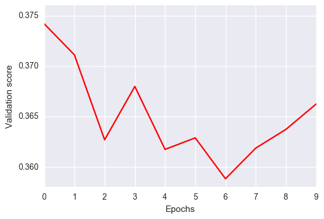

```python
import keras
import pandas as pd
from keras.layers import Dense
from keras.models import Sequential
from keras.utils import to_categorical
from keras.optimizers import SGD
import matplotlib.pyplot as plt


train = pd.read_csv("/Users/coolfish/Documents/Kaggle_Quora/features/train_magic.csv")

test=pd.read_csv("/Users/coolfish/Documents/Kaggle_Quora/features/test_magic.csv")




#Prepare the dataset
target = to_categorical(train.is_duplicate)

del train['is_duplicate']
del train['id']
del train['Unnamed: 0']
del test['id']
del test['Unnamed: 0']



predictors=train.as_matrix(columns=None)


n_cols=len(train.columns)


#buitd  the model, with two layer. neuro=100

model = Sequential()
model.add(Dense(100, activation='relu', input_shape=(n_cols,)))
model.add(Dense(100, activation='relu', input_shape=(n_cols,)))
model.add(Dense(2, activation='softmax'))



#compile the model
model.compile(optimizer='adam',
              loss='categorical_crossentropy',
              metrics=['accuracy'])


#Fix the model

mymodel=model.fit(predictors, target, validation_split=0.3)

# Visulizate the model
plt.plot(mymodel.history['val_loss'], 'r')
plt.xlabel('Epochs')
plt.ylabel('Validation score')
plt.show()
```

Logloss is around 0.36. Not bad. We can also see that the best log loss is around 6th iteration.